# Lecture #4: Functions of Several Variables

MATH 145 – Calculus I

Torin Quinlivan

tquinlivan@knox.edu

Knox College

September 24, 2025

## Functions of Several Variables

In the last few lectures, we have discussed functions of one variable of the form $y = f(x)$, such as $f(x) = 3x^2$.

These are sometimes called **single variable functions**.

These describe quantities that change depending on one other quantity. But what if we want to consider how a quantity changes if it depends on two quantities at the same time?

## Functions of Several Variables

Remember our example with the water tank in the shape of a cone?

We discussed the volume according to the radius or the height of the tank alone, because we knew the relationship between the radius and the height.

What if the company who makes the tanks is considering changing both the radius and the height? How can they model the volume of the tank for different values?
$$V(r,h) = \frac{\pi}{3} r^2 h$$

## Functions of Several Variables

A **multivariable function** is a function that depends of to *or more* variables.

A **function $f$ of $n$ independent variables** is a rule that assigns each ordered $n$-tuple $(x_1,x_2,\dots, x_n)$ in some set $D$ to exactly one real number $f(x_1,x_2,\dots, x_n)$.

## Multivariable Function as a Table

$$f(x,y) = x + 2y$$

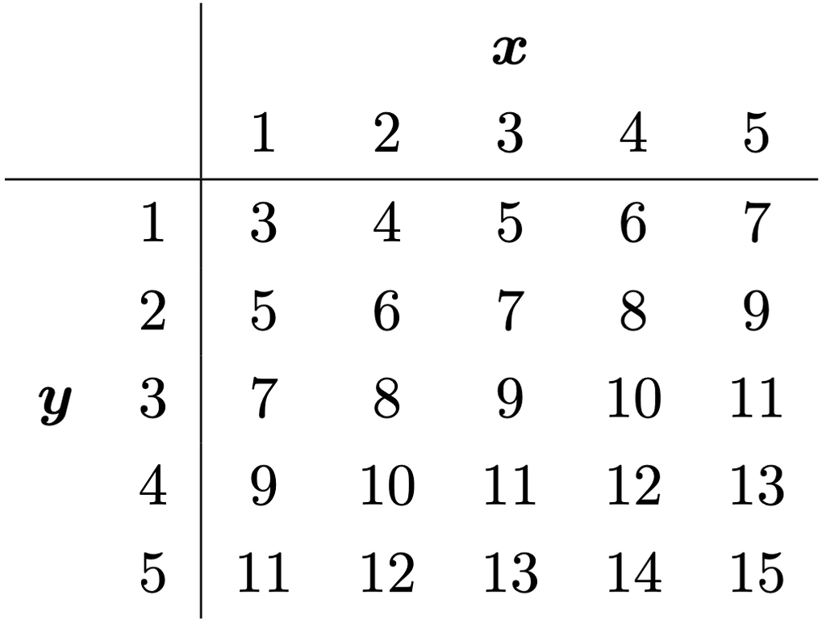

## Multivariable Function Example

$$f(x,y) = 4x^2 + 5xy - 3y^2$$

1. Find $f(3,2)$.
2. Find $f(-4,1)$.

$$g(u,v,w) = 1 + 2u + 3uv + 4uvw$$

1. Find $g(4,3,2)$.
2. Find $g(-4,-1,2)$.

## Multivariable Function Example

Suppose you invest money in an account that pays 5% interest compounded continuously. If you invest $P$ dollars in the account, the amount $A$ of money in the account after $t$ years is given by:

$$A = Pe^{0.05t}$$

The variables $P$ and $t$ are independent of each other, so using functional notation we write

$$A(P,t) = Pe^{0.05t}$$

1. Find the amount of money in the account after 7 years if you originally invest 1000 dollars.
2. Evaluate $A(5000, 8)$. What does this calculation mean?

## Multivariable Function Example

Suppose you invest money in an account that pays 5% interest compounded continuously. If you invest $P$ dollars in the account, the amount $A$ of money in the account after $t$ years is given by:

$$A(P,t) = Pe^{0.05t}$$

Now consider only the situation where the amount invested is fixed at 1000 dollars. Calculate the amount of money in the account after $t$ years to fill the table below. Round payments to the nearest penny.

| Duration (in years) | 2 | 3 | 4 | 5 | 6 |
| --- | --- | --- | --- | --- | --- |
| **Amount (in dollars)** |  |  |  |  |  |

## Multivariable Function Example

Suppose you invest money in an account that pays 5% interest compounded continuously. If you invest $P$ dollars in the account, the amount $A$ of money in the account after $t$ years is given by:
$$A(P,t) = Pe^{0.05t}$$

Now consider the situation where we want to know the amount of money in the account after 10 years given various initial investments. Calculate the amount of money in the account to fill the table below. Round payments to the nearest penny.

| Initial investment (in dollars) | 500 | 1000 | 5000 | 7500 | 10000 |
| --- | --- | --- | --- | --- | --- |
| **Amount (in dollars)** |  |  |  |  |  |

## Multivariable Function Example

Suppose you invest money in an account that pays 5% interest compounded continuously. If you invest $P$ dollars in the account, the amount $A$ of money in the account after $t$ years is given by:

$$A(P,t) = Pe^{0.05t}$$

Describe as best you can the combinations of initial investments and time that result in an account containing $\$10,000$.

## Domain, Codomain and Range

**Domain**, **codomain** and **range** are defined in the same way for multivariable functions as the are in single variable function.

$$f : \mathbb{R}^2 \to \mathbb{R}, \qquad \qquad f(x,y) = x^2 + y^2$$

**Domain:** The domain is $\mathbb{R}^2$, a.k.a. the set of all ordered pairs $(x,y)$ such that $x \in \mathbb{R}$ and $y \in \mathbb{R}$.

**Codomain:** The codomain is $\mathbb{R}$, the set of real numbers.

**Range:** The range is $\{ z : z \ge 0 \}$, the set of all $z \in \mathbb{R}$ such that $z$ is greater than or equal to 0.

## Graphing Functions of Several Variables

The volume of a cylinder with height $h$ and radius $r$ is:

$$V(r, h) = \pi r^2 h$$

How do I graph this? My screen already has two dimensions, I’ve used both of them already…

## Graphing Functions of Several Variables

We can try graphing in 3D:

[interactive chart not shown]

## Graphing Functions of Several Variables

We can also use a contour plot:

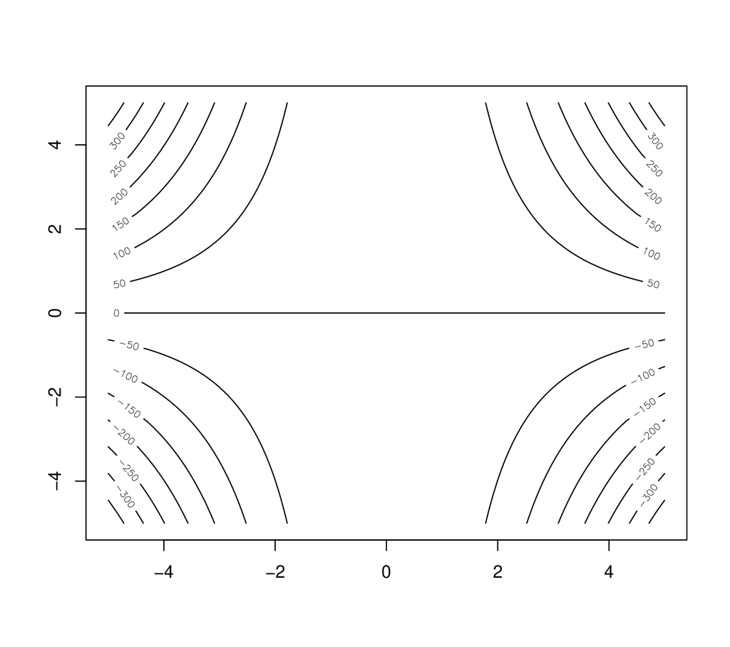

## Contour Plots

If $f(x,y)$ is a function of two variables, then a **contour plot** is a series of curves, each one corresponding to a constant $c$, where $(x,y)$ lies on the curve given by the equation $c = f(x,y)$.

## You Recognize These!

[figure not shown]

## You Recognize These!

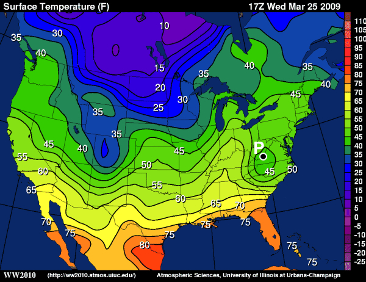

## You Recognize These!

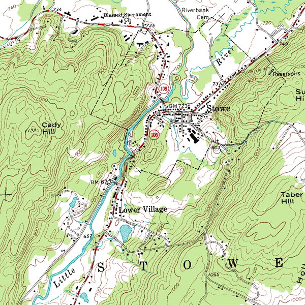

## Contour Plots of Functions

$$f(x,y) = y - x^2$$

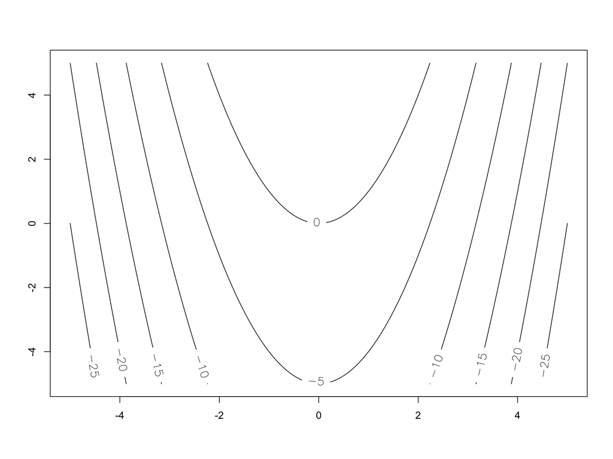

## Contour Plots of Functions

$$f(x,y) = x^2 + y^2$$

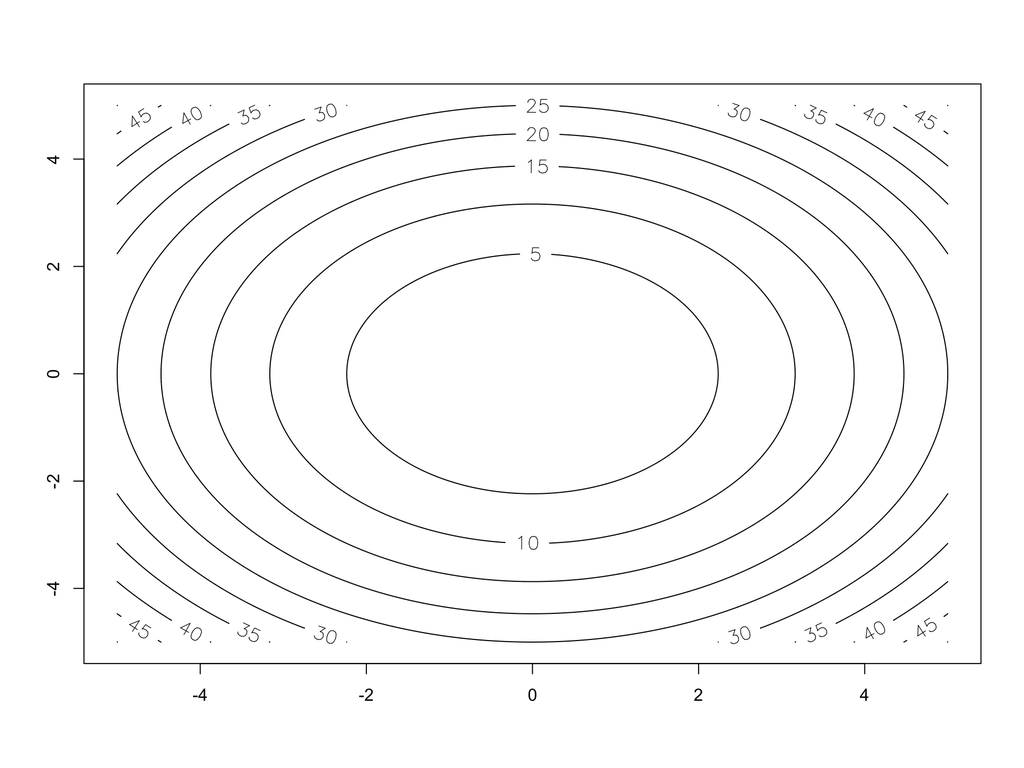

## Fixing One of the Variables

If we fix one of the variables of a function of two variables, it becomes a single variable function!
$$V(r,h) = \pi r^2 h$$

[interactive chart not shown]

## Fixing One of the Variables

If we fix $h = 1$, the cross-section becomes:

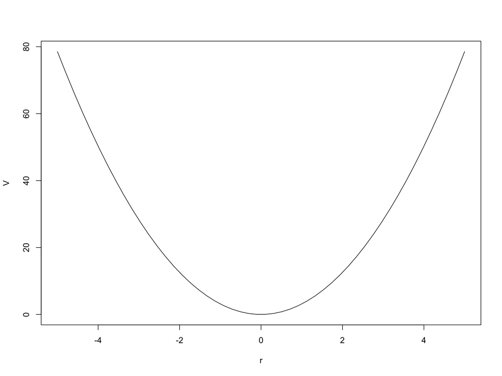

## Example

**Example:** Consider the concentration, $C$, (in $\frac{mg}{liter}$) of a drug in the blood as a function of the amount of drug given, $x$, and the time since injection, $t$. For $0 \le x \le 6$ mg and $t \ge 0$ hours, we have:

$$C(x,t) = 28t e^{-(6-x)t}$$

Find $C(3,2)$ and give a practical interpretation of your answer.